# NYPD Shooting Incident Data (Historic) [5301 - Data Science As A Field]

Gabrielle Charlton

# Introduction

This notebook is my analysis of the NYPD Shooting Incident data, obtained from the US government website, catalog.data.gov.

**Questions**

Today I am hoping to answer a few questions while exploring my data. For this I decided to have the eyes of someone who is interested in moving to New York, but is part of a vulnerable sector in the US. As a result, I want to know how safe my new home will be. The three main questions I ask are:

- What areas are the safest?
- What segment of the population of New York City most vulnerable to gun violence?
- What time of day and year are most likely correlated with increased levels of gun violence?

My goals is that these questions will give a comprehensive view on where my model person, being a black, 26 year old woman will be safe if they were to move to New York City.

**Obtain Data**

First, we imported the package “tidyverse”, which is the ,most popular package for analysis in R. Later on we will mutate date data from being a “character” to having a reproducible local time. To do this, we will also import “lubricate” at the beginning.

```r
library(tidyverse)
library(lubridate)
```

Next we use a function that will pull in data from the government page that contains historical NYPD shooting incident data. The link to the raw data is: - “https://catalog.data.gov/dataset/nypd-shooting-incident-data-historic/resource/c564b578-fd8a-4005-8365-34150d306cc4”

From this file we want to pull in one specific csv files with a specific name for easy reference. This necessary csv file, with its respective referential name is: - https://data.cityofnewyork.us/api/views/833y-fsy8/rows.csv?accessType=DOWNLOAD to NY_Data

```r
url_in <- "https://catalog.data.gov/dataset/nypd-shooting-incident-data-historic/resource/c564b578-fd8a-4005-8365-34150d306cc4"
file_name <- c("https://data.cityofnewyork.us/api/views/833y-fsy8/rows.csv?accessType=DOWNLOAD")
NY_Data <- read_csv(file_name)
```

Now we look at our New York data, to get an overview of what we were able to pull.

```r
NY_Data
```

```
## # A tibble: 27,312 x 21
##    INCIDENT_KEY OCCUR_DATE OCCUR_TIME BORO     LOC_OF_OCCUR_DESC PRECINCT
##           <dbl> <chr>      <time>     <chr>    <chr>                <dbl>
##  1    228798151 05/27/2021 21:30      QUEENS   <NA>                   105
##  2    137471050 06/27/2014 17:40      BRONX    <NA>                    40
##  3    147998800 11/21/2015 03:56      QUEENS   <NA>                   108
##  4    146837977 10/09/2015 18:30      BRONX    <NA>                    44
##  5     58921844 02/19/2009 22:58      BRONX    <NA>                    47
##  6    219559682 10/21/2020 21:36      BROOKLYN <NA>                    81
##  7     85295722 06/17/2012 22:47      QUEENS   <NA>                   114
##  8     71662474 03/08/2010 19:41      BROOKLYN <NA>                    81
##  9     83002139 02/05/2012 05:45      QUEENS   <NA>                   105
## 10     86437261 08/26/2012 01:10      QUEENS   <NA>                   101
## # ... with 27,302 more rows, and 15 more variables: JURISDICTION_CODE <dbl>,
## #   LOC_CLASSFCTN_DESC <chr>, LOCATION_DESC <chr>,
## #   STATISTICAL_MURDER_FLAG <lgl>, PERP_AGE_GROUP <chr>, PERP_SEX <chr>,
## #   PERP_RACE <chr>, VIC_AGE_GROUP <chr>, VIC_SEX <chr>, VIC_RACE <chr>,
## #   X_COORD_CD <dbl>, Y_COORD_CD <dbl>, Latitude <dbl>, Longitude <dbl>,
## #   Lon_Lat <chr>
```

```r
summary(NY_Data)
```

```
##   INCIDENT_KEY        OCCUR_DATE         OCCUR_TIME           BORO
##  Min.   :  9953245   Length:27312       Length:27312      Length:27312
##  1st Qu.: 63860880   Class :character   Class1:hms        Class :character
##  Median : 90372218   Mode  :character   Class2:difftime   Mode  :character
##  Mean   :120860536                      Mode  :numeric
##  3rd Qu.:188810230
##  Max.   :261190187
##
##  LOC_OF_OCCUR_DESC     PRECINCT      JURISDICTION_CODE LOC_CLASSFCTN_DESC
##  Length:27312       Min.   :  1.00   Min.   :0.0000    Length:27312
##  Class :character   1st Qu.: 44.00   1st Qu.:0.0000    Class :character
##  Mode  :character   Median : 68.00   Median :0.0000    Mode  :character
##                     Mean   : 65.64   Mean   :0.3269
##                     3rd Qu.: 81.00   3rd Qu.:0.0000
##                     Max.   :123.00   Max.   :2.0000
##                                      NA's   :2
##  LOCATION_DESC      STATISTICAL_MURDER_FLAG PERP_AGE_GROUP
##  Length:27312       Mode :logical           Length:27312
##  Class :character   FALSE:22046             Class :character
##  Mode  :character   TRUE :5266              Mode  :character
##
##
##
##
##    PERP_SEX          PERP_RACE         VIC_AGE_GROUP        VIC_SEX
##  Length:27312       Length:27312       Length:27312       Length:27312
##  Class :character   Class :character   Class :character   Class :character
##  Mode  :character   Mode  :character   Mode  :character   Mode  :character
##
##
##
##
##    VIC_RACE           X_COORD_CD        Y_COORD_CD        Latitude
##  Length:27312       Min.   : 914928   Min.   :125757   Min.   :40.51
##  Class :character   1st Qu.:1000029   1st Qu.:182834   1st Qu.:40.67
##  Mode  :character   Median :1007731   Median :194487   Median :40.70
##                     Mean   :1009449   Mean   :208127   Mean   :40.74
##                     3rd Qu.:1016838   3rd Qu.:239518   3rd Qu.:40.82
##                     Max.   :1066815   Max.   :271128   Max.   :40.91
##                                                        NA's   :10
##    Longitude        Lon_Lat
##  Min.   :-74.25   Length:27312
##  1st Qu.:-73.94   Class :character
##  Median :-73.92   Mode  :character
##  Mean   :-73.91
##  3rd Qu.:-73.88
##  Max.   :-73.70
##  NA's   :10
```

```r
colnames(NY_Data)
```

```
##  [1] "INCIDENT_KEY"            "OCCUR_DATE"
##  [3] "OCCUR_TIME"              "BORO"
##  [5] "LOC_OF_OCCUR_DESC"       "PRECINCT"
##  [7] "JURISDICTION_CODE"       "LOC_CLASSFCTN_DESC"
##  [9] "LOCATION_DESC"           "STATISTICAL_MURDER_FLAG"
## [11] "PERP_AGE_GROUP"          "PERP_SEX"
## [13] "PERP_RACE"               "VIC_AGE_GROUP"
## [15] "VIC_SEX"                 "VIC_RACE"
## [17] "X_COORD_CD"              "Y_COORD_CD"
## [19] "Latitude"                "Longitude"
## [21] "Lon_Lat"
```

From this, we know we have the following columns of data:

- “INCIDENT_KEY”
- “OCCUR_DATE”
- “OCCUR_TIME”
- “BORO”
- “LOC_OF_OCCUR_DESC”
- “PRECINCT”
- “JURISDICTION_CODE”
- “LOC_CLASSFCTN_DESC”
- “LOCATION_DESC”
- “STATISTICAL_MURDER_FLAG”
- “PERP_AGE_GROUP”
- “PERP_SEX”
- “PERP_RACE”
- “VIC_AGE_GROUP”
- “VIC_SEX”
- “VIC_RACE”
- “X_COORD_CD”
- “Y_COORD_CD”
- “Latitude”
- “Longitude”
- “Lon_Lat”

Based on our questions, the main columns we need are:

- “INCIDENT_KEY”
- “OCCUR_DATE”
- “OCCUR_TIME”
- “BORO”
- “JURISDICTION_CODE”
- “VIC_AGE_GROUP”
- “VIC_SEX”
- “VIC_RACE”

If we wanted to ask more questions such as:

- What is the proportional number of perpetrators’ age, race and sex versus their societal representation in the US
- What is the most likely group of people to conduct gun violence against our model person
- What is the proportional number of suspects per precinct against their age, sex and race

we can also use:

- “PERP_AGE_GROUP”
- “PERP_SEX”
- “PERP_RACE”
- “PRECINCT”

For this project, I will only stick to the three main questions I has stated at the beginning, but it would be interesting to dive in deeper later on so I will not remove them from my data frame.

## Transform and Tidy

**Omission and Transformations**

It’s best that we transform our NY_data by removing latitude data,longitude data, X and Y coordinate data, location description data, because while they would be great for creating heat maps and doing more complex geo-spatial analysis, I want to really utilize what I learned in class and work with more simplified graphs for my visualizations.

I will also be transforming the following columns to their necessary types for better analysis:

- occurrence date from a character type to a month-day-year type from a character type

```r
NY_Data <- NY_Data %>%
  select (-c(Latitude, Longitude, X_COORD_CD,Y_COORD_CD, Lon_Lat, LOC_OF_OCCUR_DESC, LOC_CLASSFCTN_DESC)) %>%
  mutate(OCCUR_DATE = mdy(OCCUR_DATE))

NY_Data
```

```
## # A tibble: 27,312 x 14
##    INCIDENT_KEY OCCUR_DATE OCCUR_TIME BORO     PRECINCT JURISDICTION_CODE
##           <dbl> <date>     <time>     <chr>       <dbl>             <dbl>
##  1    228798151 2021-05-27 21:30      QUEENS        105                 0
##  2    137471050 2014-06-27 17:40      BRONX          40                 0
##  3    147998800 2015-11-21 03:56      QUEENS        108                 0
##  4    146837977 2015-10-09 18:30      BRONX          44                 0
##  5     58921844 2009-02-19 22:58      BRONX          47                 0
##  6    219559682 2020-10-21 21:36      BROOKLYN       81                 0
##  7     85295722 2012-06-17 22:47      QUEENS        114                 0
##  8     71662474 2010-03-08 19:41      BROOKLYN       81                 0
##  9     83002139 2012-02-05 05:45      QUEENS        105                 0
## 10     86437261 2012-08-26 01:10      QUEENS        101                 0
## # ... with 27,302 more rows, and 8 more variables: LOCATION_DESC <chr>,
## #   STATISTICAL_MURDER_FLAG <lgl>, PERP_AGE_GROUP <chr>, PERP_SEX <chr>,
## #   PERP_RACE <chr>, VIC_AGE_GROUP <chr>, VIC_SEX <chr>, VIC_RACE <chr>
```

```r
summary(NY_Data)
```

```
##   INCIDENT_KEY         OCCUR_DATE          OCCUR_TIME           BORO
##  Min.   :  9953245   Min.   :2006-01-01   Length:27312      Length:27312
##  1st Qu.: 63860880   1st Qu.:2009-07-18   Class1:hms        Class :character
##  Median : 90372218   Median :2013-04-29   Class2:difftime   Mode  :character
##  Mean   :120860536   Mean   :2014-01-06   Mode  :numeric
##  3rd Qu.:188810230   3rd Qu.:2018-10-15
##  Max.   :261190187   Max.   :2022-12-31
##
##     PRECINCT      JURISDICTION_CODE LOCATION_DESC      STATISTICAL_MURDER_FLAG
##  Min.   :  1.00   Min.   :0.0000    Length:27312       Mode :logical
##  1st Qu.: 44.00   1st Qu.:0.0000    Class :character   FALSE:22046
##  Median : 68.00   Median :0.0000    Mode  :character   TRUE :5266
##  Mean   : 65.64   Mean   :0.3269
##  3rd Qu.: 81.00   3rd Qu.:0.0000
##  Max.   :123.00   Max.   :2.0000
##                   NA's   :2
##  PERP_AGE_GROUP       PERP_SEX          PERP_RACE         VIC_AGE_GROUP
##  Length:27312       Length:27312       Length:27312       Length:27312
##  Class :character   Class :character   Class :character   Class :character
##  Mode  :character   Mode  :character   Mode  :character   Mode  :character
##
##
##
##
##    VIC_SEX            VIC_RACE
##  Length:27312       Length:27312
##  Class :character   Class :character
##  Mode  :character   Mode  :character
##
##
##
##
```

## Visualizations

**Question 1: What areas are the safest?**

For this question, I want to see what areas are the safest (and alternatively, not the safest) in New York for my person to move to. For this I will need:

- the different boroughs
- The corresponding number of cases per borough

First, let’s count the number of cases in the entire dataframe:

```r
num_entries <- nrow(NY_Data)
num_entries
```

```
## [1] 27312
```

Now let’s look at how many cases are associated with each borough.

```r
boro_cases <- NY_Data %>%
  group_by(BORO) %>%
  tally()

boro_cases
```

```
## # A tibble: 5 x 2
##   BORO              n
##   <chr>         <int>
## 1 BRONX          7937
## 2 BROOKLYN      10933
## 3 MANHATTAN      3572
## 4 QUEENS         4094
## 5 STATEN ISLAND   776
```

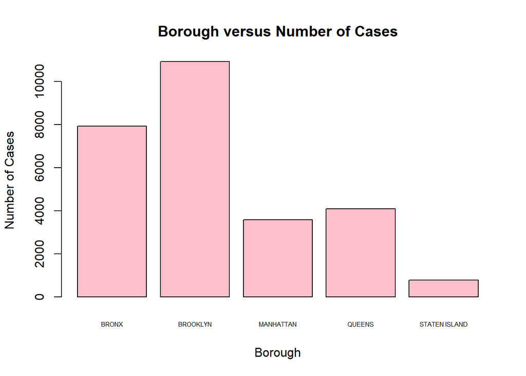

```r
barplot(n~BORO,
        aggregate(n~BORO, boro_cases, sum),
        main="Borough versus Number of Cases",
        xlab="Borough",
        ylab="Number of Cases",
        cex.names=0.5,
        col = "pink")
```

[figure not shown]

```r
ggplot(NY_Data, aes(x = BORO, y = STATISTICAL_MURDER_FLAG, fill = STATISTICAL_MURDER_FLAG, colour = STATISTICAL_MURDER_FLAG)) +
  geom_bar(stat = "identity")+
  theme(axis.text.x = element_text(angle = 90)) +
  labs(title = "Statistical Murder Flag per Borough versus Number of Cases",
       x = "Borough",
       y = "Number of Cases")
```

**Question 2: What segment of the population of New York City is most vulnerable to gun violence?**

Now that we’ve dived into the locations’ aspects, let’s try to answer the question on our model herself for what is the most vulnerable segment to gun violence in New York. We know our overall population for this data set is 27,312. Let’s use:

```r
race_cases <- NY_Data %>%
  group_by(VIC_RACE) %>%
  count()

race_cases
```

```
## # A tibble: 7 x 2
## # Groups:   VIC_RACE [7]
##   VIC_RACE                           n
##   <chr>                          <int>
## 1 AMERICAN INDIAN/ALASKAN NATIVE    10
## 2 ASIAN / PACIFIC ISLANDER         404
## 3 BLACK                          19439
## 4 BLACK HISPANIC                  2646
## 5 UNKNOWN                           66
## 6 WHITE                            698
## 7 WHITE HISPANIC                  4049
```

```r
age_cases <- NY_Data %>%
  group_by(VIC_AGE_GROUP) %>%
  count()

age_cases
```

```
## # A tibble: 7 x 2
## # Groups:   VIC_AGE_GROUP [7]
##   VIC_AGE_GROUP     n
##   <chr>         <int>
## 1 <18            2839
## 2 1022              1
## 3 18-24         10086
## 4 25-44         12281
## 5 45-64          1863
## 6 65+             181
## 7 UNKNOWN          61
```

```r
sex_cases <- NY_Data %>%
  group_by(VIC_SEX) %>%
  count()

sex_cases
```

```
## # A tibble: 3 x 2
## # Groups:   VIC_SEX [3]
##   VIC_SEX     n
##   <chr>   <int>
## 1 F        2615
## 2 M       24686
## 3 U          11
```

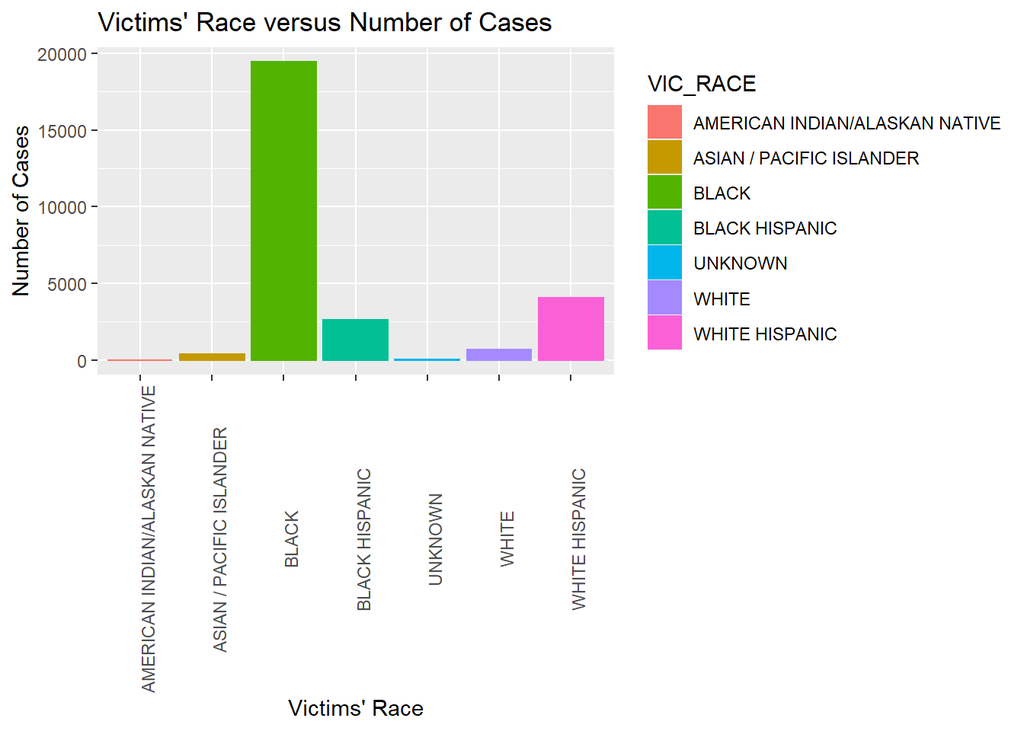

```r
#barplot(n~VIC_RACE, aggregate(n~VIC_RACE, race_cases, sum))
ggplot(race_cases, aes(x = VIC_RACE, y = n, fill= VIC_RACE, colour = VIC_RACE)) +
  geom_bar(stat = "identity")+
  theme(axis.text.x = element_text(angle = 90)) +
  labs(title = "Victims' Race versus Number of Cases",
       x = "Victims' Race",
       y = "Number of Cases")
```

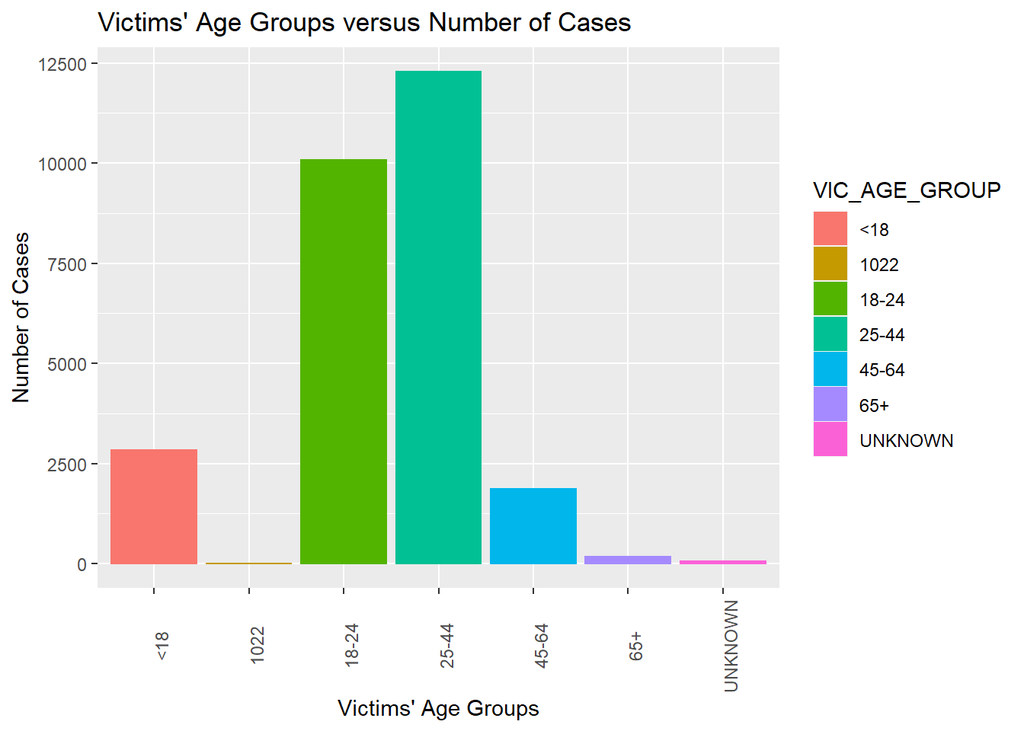

```r
ggplot(age_cases, aes(x = VIC_AGE_GROUP, y = n, fill= VIC_AGE_GROUP, colour = VIC_AGE_GROUP)) +
  geom_bar(stat = "identity")+
  theme(axis.text.x = element_text(angle = 90)) +
  labs(title = "Victims' Age Groups versus Number of Cases",
       x = "Victims' Age Groups",
       y = "Number of Cases")
```

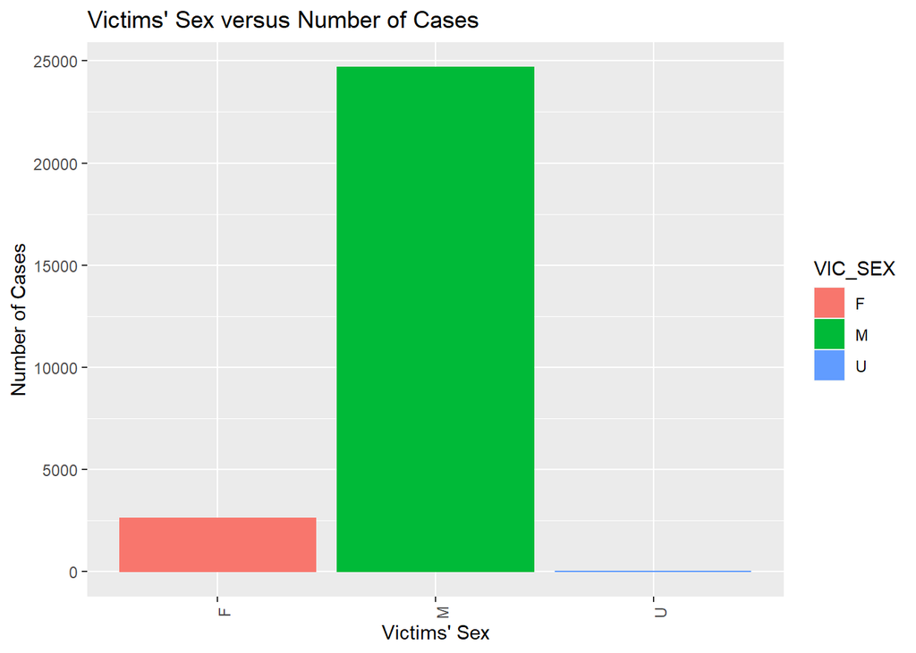

```r
ggplot(sex_cases, aes(x = VIC_SEX, y = n, fill= VIC_SEX, colour = VIC_SEX)) +
  geom_bar(stat = "identity") +
  theme(axis.text.x = element_text(angle = 90)) +
  labs(title = "Victims' Sex versus Number of Cases",
       x = "Victims' Sex",
       y = "Number of Cases")
```

**Summary of Question 2** It looks like the most vulnerable group of people in New York to gun violence is black men withing the 18 to 44 age range. Considering our model person is a black person with the 18 to 44 age range, she is statistically more likely to experience gun violence if she were to move to New York based on two out of three of her characteristics.

**Question 3: What time of day and year are most likely correlated with increased levels of gun violence?** What should our model person consider about her behaviors while there? Here we will dive into the best conditions our person should consider when moving in order to be the safest she can be. I want to look at the number of cases in comparison to the hour, day and month, so our model knows when to be most cautious.

```r
#df$month <- month(mdy(df$date))
NY_Data$Occur_day <- wday(NY_Data$OCCUR_DATE) #already transformed earlier
NY_Data$Occur_month <- month(NY_Data$OCCUR_DATE)
NY_Data$Occur_hour <-  hour(hms(as.character(NY_Data$OCCUR_TIME)))

day_cases <- NY_Data %>%
  group_by(Occur_day) %>%
  count()

month_cases <- NY_Data %>%
  group_by(Occur_month) %>%
  count()

hour_cases <- NY_Data %>%
  group_by(Occur_hour) %>%
  count()

day_cases
```

```
## # A tibble: 7 x 2
## # Groups:   Occur_day [7]
##   Occur_day     n
##       <dbl> <int>
## 1         1  5452
## 2         2  3883
## 3         3  3163
## 4         4  3000
## 5         5  3034
## 6         6  3585
## 7         7  5195
```

```r
month_cases
```

```
## # A tibble: 12 x 2
## # Groups:   Occur_month [12]
##    Occur_month     n
##          <dbl> <int>
##  1           1  1716
##  2           2  1340
##  3           3  1688
##  4           4  1983
##  5           5  2571
##  6           6  2829
##  7           7  3238
##  8           8  3156
##  9           9  2572
## 10          10  2279
## 11          11  1944
## 12          12  1996
```

```r
hour_cases
```

```
## # A tibble: 24 x 2
## # Groups:   Occur_hour [24]
##    Occur_hour     n
##         <dbl> <int>
##  1          0  2186
##  2          1  2081
##  3          2  1812
##  4          3  1633
##  5          4  1441
##  6          5   702
##  7          6   366
##  8          7   233
##  9          8   238
## 10          9   217
## # ... with 14 more rows
```

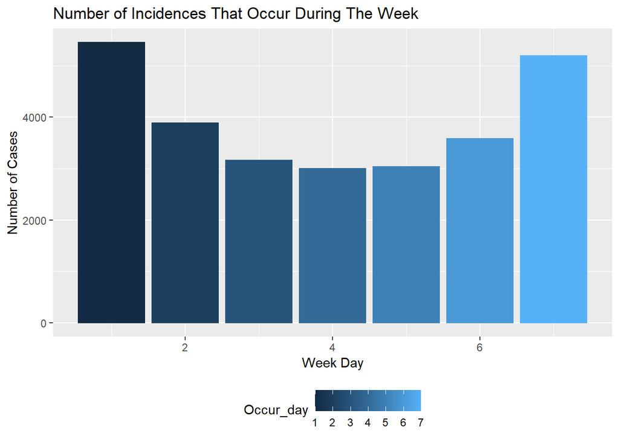

```r
ggplot(day_cases, aes(x = Occur_day, y = n, fill= Occur_day, colour = Occur_day)) +
  geom_bar(stat = "identity")+
  theme(legend.position = "bottom") +
  labs(title = "Number of Incidences That Occur During The Week",
       x = "Week Day",
       y = "Number of Cases")
```

From our data, it looks like the most dangerous day for gun violence is on the weekends, Saturday and Sunday, and the lowest is Wednesday.

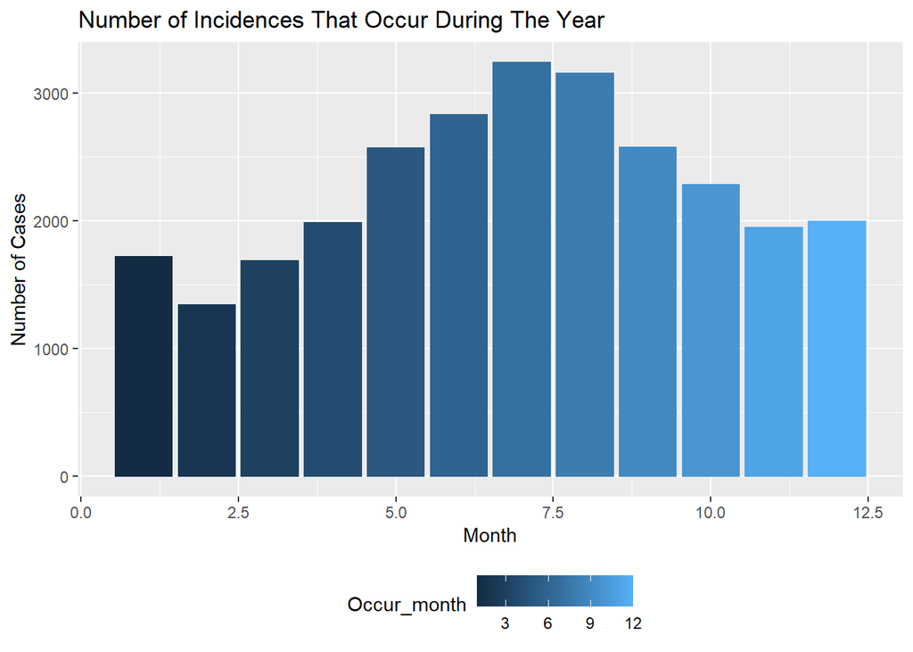

```r
ggplot(month_cases, aes(x = Occur_month, y = n, fill= Occur_month, colour = Occur_month)) +
  geom_bar(stat = "identity")+
    theme(legend.position = "bottom") +
  labs(title = "Number of Incidences That Occur During The Year",
       x = "Month",
       y = "Number of Cases")
```

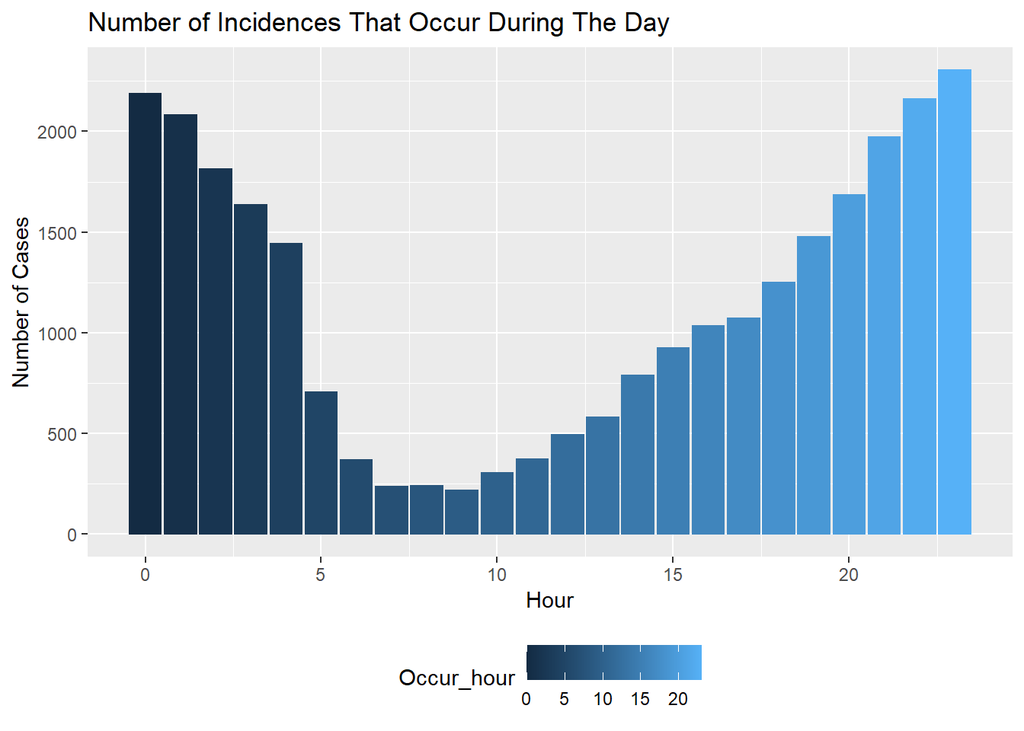

```r
ggplot(hour_cases, aes(x = Occur_hour, y = n, fill= Occur_hour, colour = Occur_hour)) +
  geom_bar(stat = "identity")+
    theme(legend.position = "bottom") +
  labs(title = "Number of Incidences That Occur During The Day",
       x = "Hour",
       y = "Number of Cases")
```

From our data, it looks like the most dangerous hours for gun violence are in the middle of the night between 9pm and 1am, and the lowest is morning until afternoon between 6am and 12pm.

**Summary of Question 3** These trends are very interesting because it really showcases human behaviors. During midyear, school is out, the weather is mostly favorable and travel is pretty high, resulting i more common foot traffic. During the weekend, there is usually more people free and available as well, which we can substantiate through our findings. The opposite can be said during February where it is usually the middle of winter, and going outside is less favorable. The same for our hours analysis, where the hours people are usually asleep and there is less foot traffic/ witnesses, gun violence tends to be higher.

In conclusion, the most favorable environment for gun violence to occur is during a time when people are generally free from school/ work (weekends), more mobile (mid-year) and have less witnesses to their crimes (late at night). If our model person wants to move to New York, knowing what conditions she should consider for her environment in order to be safe will better arm her with making the right decision for her.

### Bias

The bias that I had going into this two fold. I am very aware of the systematic racism at play in the US, primarily against black people, and my initial reaction to having to do this as my project was feeling uncomfortable and that I wouldn’t be able to give this serious topic enough grace it deserves. Another thing I had was a lack knowledge of the actual culture in New York, as I’ve never been there and have only gathered residual information from the media (tv shows, movies, etc.). I think creating a character with my characteristics (a black 26 year old woman looking to move to a new city) really helped me to step outside of my comfort zone and helped me to build confidence to try something new.

## Conclusion

In conclusion, I was able to begin answering the three questions I had set:

**What segment of the population of New York City most vulnerable to gun violence?** From the analysis, it looks like the segment of the population most vulnerable to gun violence are black men within teh 18 to 44 age range. Considering my model is a 26 year old black woman, having two out of three characteristics with a high statistical chance of being hurt by gun violence does help give the model some perspective on what to choose.

**What would I suggest to my model?** Currently, I think this analysis *begins* to answer questions, but with more data and background knowledge, I’m certain I will be able to give a more comprehensive idea on the best choice for my model on where she should deiced to live.

**Next steps?** I would love to work on this data set in the future, possible answering some of the additional questions I asked earlier on in the report.